# R Notebook

# Consider sales data, perform Exploratory Data Analysis (EDA) and Feature Engineering

using appropriate techniques and variables

## The data set

```r
library(readxl)
Sales_Data <- read_excel("Sales_Data.xlsx")
View(Sales_Data)
head(Sales_Data)
```

| manufact | model | sales | resale | type | price | engine_s | horsepow | wheelbas | width | length | curb_wgt | fuel_cap | mpg | Grp_Horse |
| --- | --- | --- | --- | --- | --- | --- | --- | --- | --- | --- | --- | --- | --- | --- |
| Chevrolet | Metro | 21.855 | 5.16 | 0 | 9.2349999999999994 | 1 | 55 | 93.1 | 62.6 | 149.4 | 1.895 | 10.3 | 45 | 1 |
| Hyundai | Accent | 41.183999999999997 | 5.86 | 0 | 9.6989999999999998 | 1.5 | 92 | NULL! | 65.7 | 166.7 | 2.2400000000000002 | 11.9 | 31 | NULL! |
| Saturn | SL | 80.62 | 9.1999999999999993 | 0 | 10.685 | 1.9 | 100 | 102.4 | 66.400000000000006 | 176.9 | NULL! | 12.1 | 33 | 1 |
| Saturn | SC | 24.545999999999999 | 10.59 | 0 | 12.535 | 1.9 | 100 | 102.4 | 66.400000000000006 | 180 | 2.367 | 12.1 | NULL! | 1 |
| NULL! | Integra | 16.919 | 16.36 | 0 | 21.5 | 1.8 | 140 | 101.2 | 67.3 | 172.4 | 2.6389999999999998 | NULL! | 28 | 2 |
| Audi | A4 | 20.396999999999998 | 22.254999999999999 | 0 | 23.99 | 1.8 | 150 | 102.6 | 68.2 | 178 | 2.9980000000000002 | 16.399999999999999 | 27 | 2 |

## Summary of the data set

### Columns of the data set

```r
colnames(Sales_Data)
```

```
##  [1] "manufact"  "model"     "sales"     "resale"    "type"      "price"
##  [7] "engine_s"  "horsepow"  "wheelbas"  "width"     "length"    "curb_wgt"
## [13] "fuel_cap"  "mpg"       "Grp_Horse"
```

### Convert the number column data to the numeric values

```r
numeric_cols = c("sales","resale","type","price", "engine_s", "horsepow",  "wheelbas",  "width", "length", "curb_wgt", "fuel_cap","mpg",  "Grp_Horse")
Sales_Data[, numeric_cols] = lapply(Sales_Data[,numeric_cols], as.numeric)
```

[output not shown]

```r
str(Sales_Data)
```

```
## tibble [157 × 15] (S3: tbl_df/tbl/data.frame)
##  $ manufact : chr [1:157] "Chevrolet" "Hyundai" "Saturn" "Saturn" ...
##  $ model    : chr [1:157] "Metro" "Accent" "SL" "SC" ...
##  $ sales    : num [1:157] 21.9 41.2 80.6 24.5 16.9 ...
##  $ resale   : num [1:157] 5.16 5.86 9.2 10.59 16.36 ...
##  $ type     : num [1:157] 0 0 0 0 0 0 0 0 0 0 ...
##  $ price    : num [1:157] 9.23 9.7 10.69 12.54 21.5 ...
##  $ engine_s : num [1:157] 1 1.5 1.9 1.9 1.8 1.8 2.2 1.8 2 2 ...
##  $ horsepow : num [1:157] 55 92 100 100 140 150 115 120 132 132 ...
##  $ wheelbas : num [1:157] 93.1 NA 102.4 102.4 101.2 ...
##  $ width    : num [1:157] 62.6 65.7 66.4 66.4 67.3 68.2 67.9 66.7 71 74.4 ...
##  $ length   : num [1:157] 149 167 177 180 172 ...
##  $ curb_wgt : num [1:157] 1.9 2.24 NA 2.37 2.64 ...
##  $ fuel_cap : num [1:157] 10.3 11.9 12.1 12.1 NA 16.4 14.3 13.2 16 12.5 ...
##  $ mpg      : num [1:157] 45 31 33 NA 28 27 27 33 27 29 ...
##  $ Grp_Horse: num [1:157] 1 NA 1 1 2 2 2 2 2 2 ...
```

### Data set distribution

```r
summary(Sales_Data)
```

```
##    manufact            model               sales            resale
##  Length:157         Length:157         Min.   :  0.11   Min.   : 5.16
##  Class :character   Class :character   1st Qu.: 13.96   1st Qu.:11.26
##  Mode  :character   Mode  :character   Median : 29.45   Median :14.18
##                                        Mean   : 53.91   Mean   :18.07
##                                        3rd Qu.: 69.32   3rd Qu.:19.88
##                                        Max.   :540.56   Max.   :67.55
##                                        NA's   :6        NA's   :36
##       type          price           engine_s        horsepow
##  Min.   :0.00   Min.   : 9.235   Min.   :1.000   Min.   : 55.0
##  1st Qu.:0.00   1st Qu.:18.176   1st Qu.:2.300   1st Qu.:149.0
##  Median :0.00   Median :23.099   Median :3.000   Median :180.0
##  Mean   :0.26   Mean   :27.646   Mean   :3.054   Mean   :186.6
##  3rd Qu.:1.00   3rd Qu.:32.831   3rd Qu.:3.500   3rd Qu.:215.0
##  Max.   :1.00   Max.   :85.500   Max.   :8.000   Max.   :450.0
##  NA's   :7      NA's   :7        NA's   :4       NA's   :6
##     wheelbas         width           length         curb_wgt
##  Min.   : 92.6   Min.   :62.60   Min.   :149.4   Min.   :1.895
##  1st Qu.:103.0   1st Qu.:68.47   1st Qu.:178.0   1st Qu.:2.990
##  Median :107.0   Median :70.60   Median :188.2   Median :3.368
##  Mean   :107.5   Mean   :71.19   Mean   :187.8   Mean   :3.393
##  3rd Qu.:112.0   3rd Qu.:73.53   3rd Qu.:196.4   3rd Qu.:3.821
##  Max.   :138.7   Max.   :79.90   Max.   :224.5   Max.   :5.572
##  NA's   :7       NA's   :5       NA's   :7       NA's   :8
##     fuel_cap          mpg          Grp_Horse
##  Min.   :10.30   Min.   :15.00   Min.   :1.000
##  1st Qu.:15.90   1st Qu.:21.00   1st Qu.:2.000
##  Median :17.35   Median :24.00   Median :3.000
##  Mean   :18.05   Mean   :23.76   Mean   :3.311
##  3rd Qu.:19.80   3rd Qu.:26.00   3rd Qu.:4.000
##  Max.   :32.00   Max.   :45.00   Max.   :9.000
##  NA's   :7       NA's   :6       NA's   :9
```

## Missing values in each column

```r
num_col = Sales_Data[,numeric_cols]
str_col = Sales_Data[,1:2]

missing_data = data.frame(columns = colnames(str_col),
                          missing_val = colSums(str_col == "NULL"),
                          perc_missing = colMeans(str_col == "NULL"))
num_miss = data.frame(columns = colnames(num_col),
                          missing_val = colSums(is.na(num_col)),
                          perc_missing = colMeans(is.na(num_col)))

missing_data = rbind(missing_data, num_miss)
View(missing_data)
missing_data
```

|  | columns | missing_val | perc_missing |
| --- | --- | --- | --- |
| manufact | manufact | 0 | 0.00000000 |
| model | model | 0 | 0.00000000 |
| sales | sales | 6 | 0.03821656 |
| resale | resale | 36 | 0.22929936 |
| type | type | 7 | 0.04458599 |
| price | price | 7 | 0.04458599 |
| engine_s | engine_s | 4 | 0.02547771 |
| horsepow | horsepow | 6 | 0.03821656 |
| wheelbas | wheelbas | 7 | 0.04458599 |
| width | width | 5 | 0.03184713 |

[output cut: 5 more lines]

```r
# check for na
any(is.na(Sales_Data))
```

```
## [1] TRUE
```

```r
# check for null
any(is.null(Sales_Data))
```

```
## [1] FALSE
```

The data has missing values represented as `Null!` and not any of the default `NA` and `NULL`

The data has no column with more than half the values in the column missing so no columns or rows need to be dropped

## Number of data points

```r
ncol(Sales_Data)
```

```
## [1] 15
```

```r
nrow(Sales_Data)
```

```
## [1] 157
```

```r
ncol(Sales_Data) * ncol(Sales_Data)
```

```
## [1] 225
```

## Unique manufacturers

### Impute the NULL manufacturers

This is done by imputing the previously observed value in the column

```r
library(zoo)
Sales_Data$manufact[Sales_Data$manufact == "NULL!"] = NA
Sales_Data$manufact = na.locf(Sales_Data$manufact)

# confirm if any na are in the manufact column
any(is.na(Sales_Data$manufact))
```

```
## [1] FALSE
```

### The number of manufacturers

```r
unique(Sales_Data$manufact)
```

```
##  [1] "Chevrolet"     "Hyundai"       "Saturn"        "Audi"
##  [5] "Chrysler"      "Dodge"         "Ford"          "Honda"
##  [9] "Jeep"          "Mitsubishi"    "Mercury"       "Nissan"
## [13] "Oldsmobile"    "Plymouth"      "Pontiac"       "Toyota"
## [17] "Volkswagen"    "BMW"           "Buick"         "Mercedes-Benz"
## [21] "Saab"          "Subaru"        "Volvo"         "Acura"
## [25] "Cadillac"      "Infiniti"      "Jaguar"        "Lexus"
## [29] "Lincoln"       "Porsche"
```

There are `30` unique car manufacturers

## Cars produced by each manufacturer

```r
cars = data.frame(manufact = Sales_Data$manufact,
                  model = Sales_Data$model,
                  count = rep(1, 157))
library(dplyr)
cars = cars %>% group_by(manufact) %>%summarise(count = sum(count))
```

### See the cars produced

```r
cars
```

| manufact | count |
| --- | --- |
| Acura | 3 |
| Audi | 3 |
| BMW | 3 |
| Buick | 4 |
| Cadillac | 5 |
| Chevrolet | 9 |
| Chrysler | 7 |
| Dodge | 11 |
| Ford | 11 |
| Honda | 5 |

[output cut: 20 more lines]

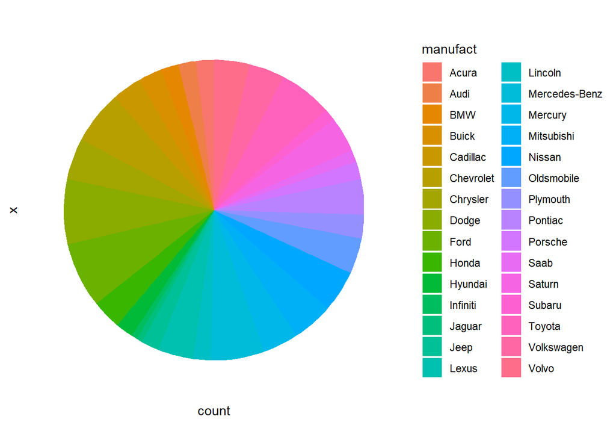

```r
library(ggplot2)

ggplot(cars, aes(x= "", y = count, fill = manufact))+
  geom_bar(stat = "identity", width = 1)+
  coord_polar("y", start = 0)+
  theme_classic() +
  theme(axis.line = element_blank(),
          axis.text = element_blank(),
          axis.ticks = element_blank())
```

## Assessing the numeric columns

```r
colnames(Sales_Data[,numeric_cols])
```

```
##  [1] "sales"     "resale"    "type"      "price"     "engine_s"  "horsepow"
##  [7] "wheelbas"  "width"     "length"    "curb_wgt"  "fuel_cap"  "mpg"
## [13] "Grp_Horse"
```

### Separate factor and number columns

**Discrete/ Factor Columns**

1. Type
2. Grp_Horse
3. engine_s
4. horsepow
5. mpg

These are imputed with the modal value

### Continuous columns

1. sales
2. resale
3. price
4. wheelbas
5. width
6. length
7. curb_wgt
8. fuel_cap

### imputation of discrete / factor using mode

```r
# distribution plot function
plot_distrib = function(col_name){
  # convert the data into columns
  col_vals = data.frame(table(col_name))
  col_vals$percent = col_vals$Freq / sum(col_vals$Freq) * 100
  # plot the distibution
  plot = ggplot(col_vals, aes(x = "", y = Freq, fill = as.factor(as.character(col_name)))) +
    geom_bar(stat = "identity") +
    coord_polar("y") +
    geom_text(aes(label = paste0(round(percent), "%")), position = position_stack(vjust = 0.5)) +
    ggtitle("Distribution Percentages") +
    theme_light()
  return(plot)
}
```

```r
# imputation func
calc_mod = function(x){
  uniq_x = unique(x)
  uniq_x[which.max(tabulate(match(x, uniq_x)))]
}
```

1. **Type**

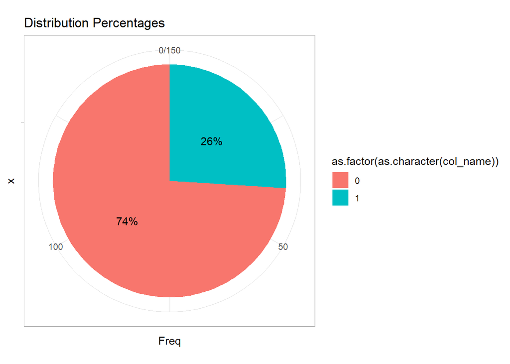

```r
plot_distrib(Sales_Data$type)
```

```r
Sales_Data$type = ifelse(is.na(Sales_Data$type), calc_mod(Sales_Data$type), Sales_Data$type)

# Check if any na is left in the column
if(any(is.na(Sales_Data$type))){
  print("There are still na values in: type")
}else{
  print("No na values in: type")
}
```

```
## [1] "No na values in: type"
```

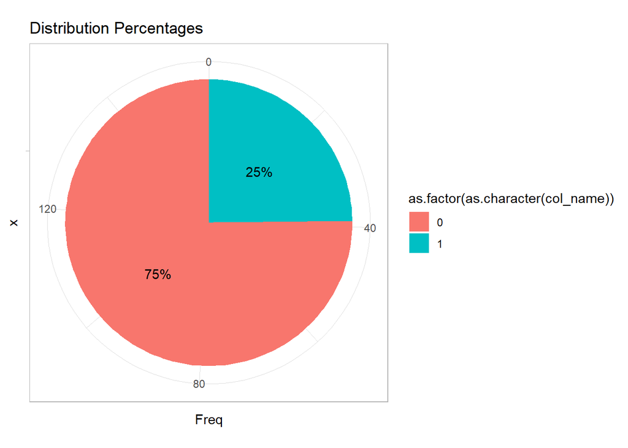

```r
# replot the distribution to see if it is consistent
plot_distrib(Sales_Data$type)
```

2. **Grp_Hourse**

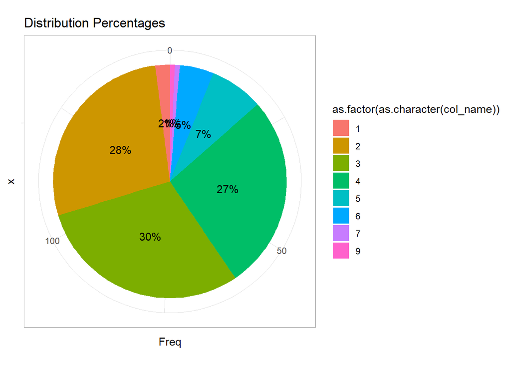

```r
plot_distrib(Sales_Data$Grp_Horse)
```

```r
Sales_Data$Grp_Horse = ifelse(is.na(Sales_Data$Grp_Horse), calc_mod(Sales_Data$Grp_Horse), Sales_Data$Grp_Horse)

# Check if any na is left in the column
if(any(is.na(Sales_Data$Grp_Horse))){
  print("There are still na values in: Grp_Horse")
}else{
  print("No na values in: Grp_Horse")
}
```

```
## [1] "No na values in: Grp_Horse"
```

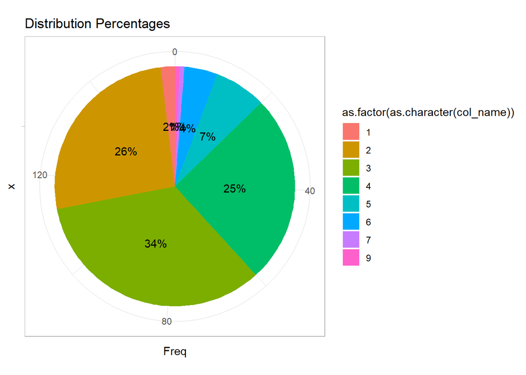

```r
# replot the distribution to see if it is consistent
plot_distrib(Sales_Data$Grp_Horse)
```

3. **engine_s**

```r
plot_density = function(data_set,num_col){
  ggplot(data_set, aes(x = data_set[[num_col]]))+
    geom_density(fill = "lightblue", color = "blue")+
    ggtitle(paste("Density Plot of", num_col))+
    xlab(num_col)+
    ylab("Density")+
    theme_minimal()
}
```

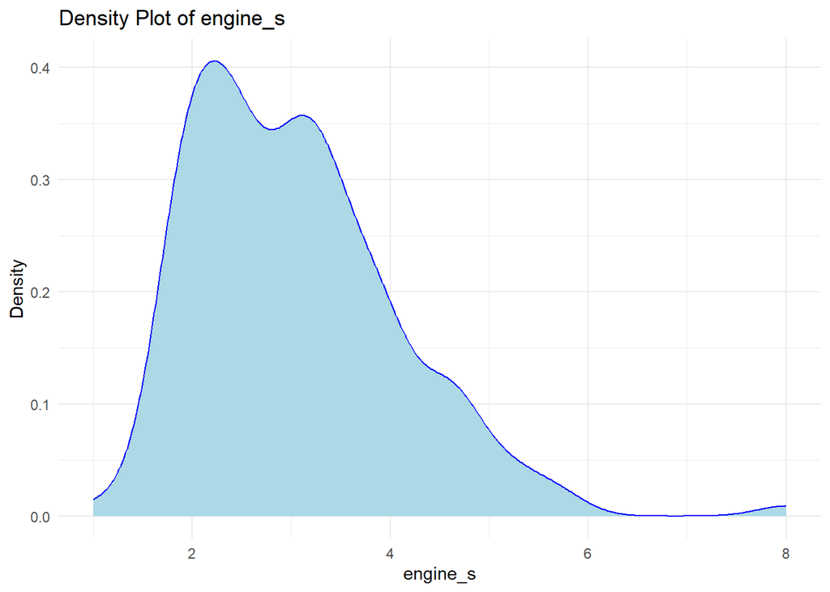

```r
plot_density(Sales_Data,"engine_s")
```

```r
Sales_Data$engine_s = ifelse(is.na(Sales_Data$engine_s), calc_mod(Sales_Data$engine_s), Sales_Data$engine_s)

# Check if any na is left in the column
if(any(is.na(Sales_Data$engine_s))){
  print("There are still na values in: engine_s")
}else{
  print("No na values in: engine_s")
}
```

```
## [1] "No na values in: engine_s"
```

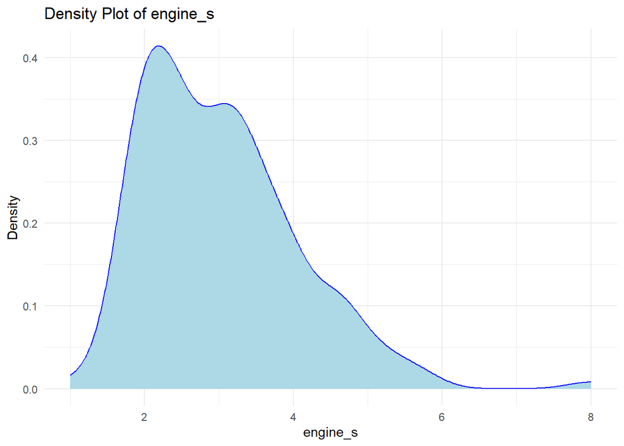

```r
# replot the distribution to see if it is consistent
plot_density(Sales_Data,"engine_s")
```

4. **horsepow**

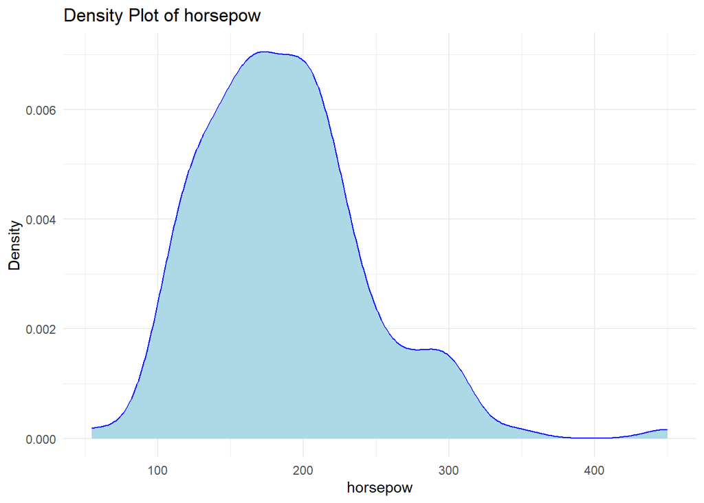

```r
plot_density(Sales_Data,"horsepow")
```

```r
Sales_Data$horsepow = ifelse(is.na(Sales_Data$horsepow), calc_mod(Sales_Data$horsepow), Sales_Data$horsepow)

# Check if any na is left in the column
if(any(is.na(Sales_Data$horsepow))){
  print("There are still na values in: horsepow")
}else{
  print("No na values in: horsepow")
}
```

```
## [1] "No na values in: horsepow"
```

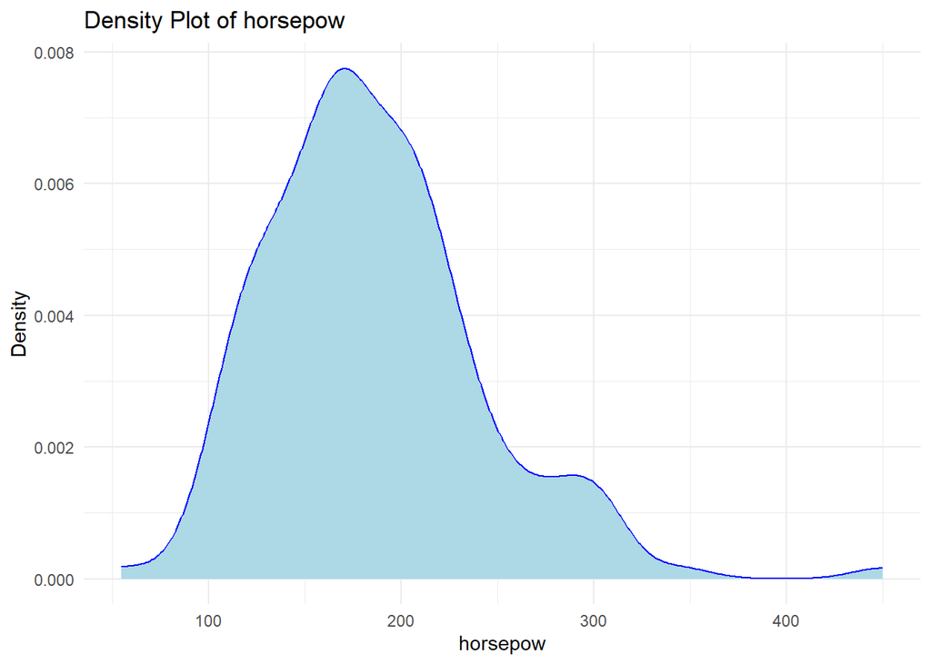

```r
# replot the distribution to see if it is consistent
plot_density(Sales_Data,"horsepow")
```

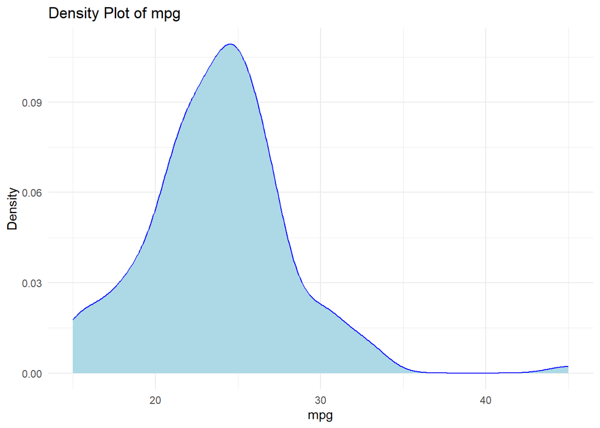

```r
plot_density(Sales_Data,"mpg")
```

```r
Sales_Data$mpg = ifelse(is.na(Sales_Data$mpg), calc_mod(Sales_Data$mpg), Sales_Data$mpg)

# Check if any na is left in the column
if(any(is.na(Sales_Data$mpg))){
  print("There are still na values in: mpg")
}else{
  print("No na values in: mpg")
}
```

```
## [1] "No na values in: mpg"
```

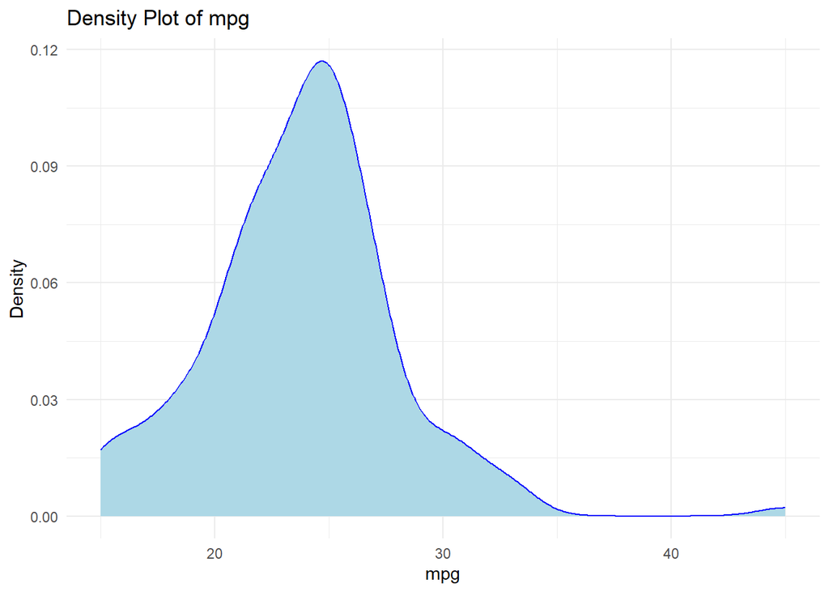

```r
# replot the distribution to see if it is consistent
plot_density(Sales_Data,"mpg")
```

### Imputing continuous columns

using a random value based on the number of na values in the column

```r
set.seed(123)
rand_val = function(data, column_name, low, up){
  data[[column_name]] = ifelse(is.na(data[[column_name]]), runif(sum(is.na(data[[column_name]])), min = low, max = up), data[[column_name]])
  return(data)
}
```

1 **sales**

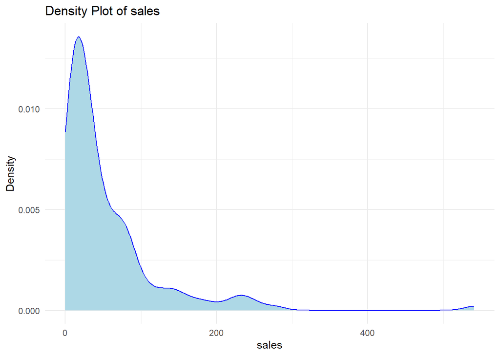

```r
plot_density(Sales_Data, "sales")
```

```r
Sales_Data=rand_val(Sales_Data, "sales",
             min(Sales_Data$sales, na.rm = TRUE),
             max(Sales_Data$sales, na.rm = TRUE))

if(any(is.na(Sales_Data$sales))){
  print(paste("there are na values", "sales"))
}else{
  print(paste("no na values", "sales"))
}
```

```
## [1] "no na values sales"
```

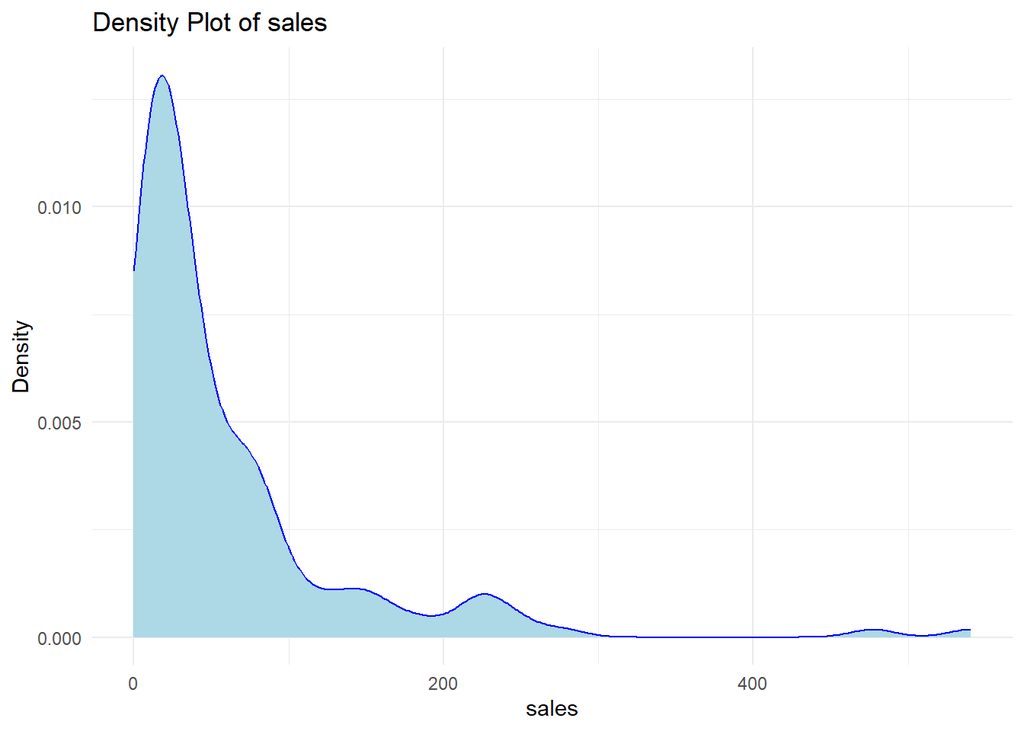

```r
plot_density(Sales_Data, "sales")
```

2. **resale**

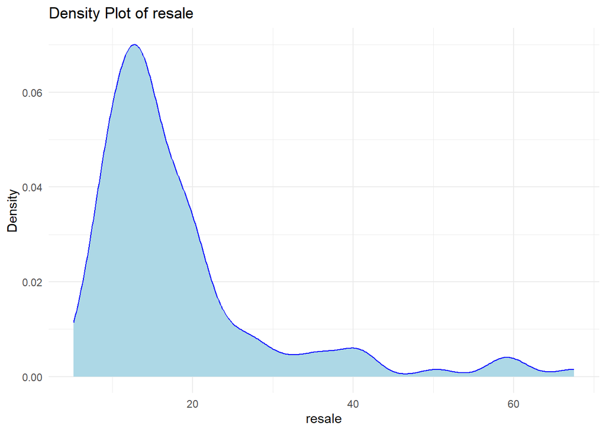

```r
plot_density(Sales_Data, "resale")
```

```r
Sales_Data=rand_val(Sales_Data, "resale",
             min(Sales_Data$resale, na.rm = TRUE),
             max(Sales_Data$resale, na.rm = TRUE))

if(any(is.na(Sales_Data$resale))){
  print(paste("there are na values", "resale"))
}else{
  print(paste("no na values", "resale"))
}
```

```
## [1] "no na values resale"
```

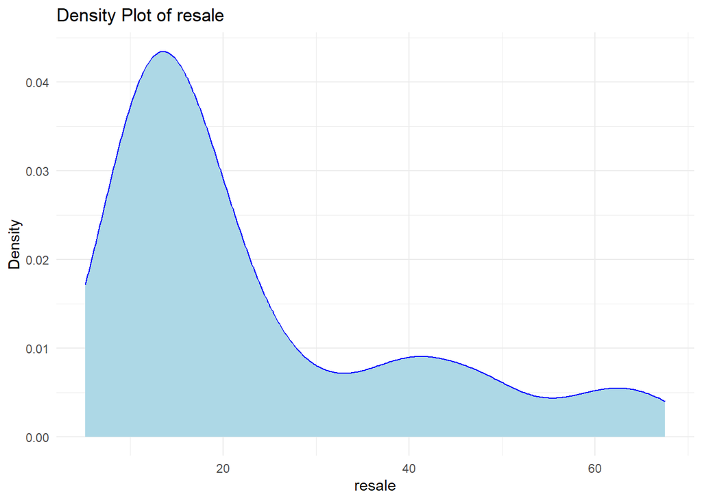

```r
plot_density(Sales_Data, "resale")
```

3. **price**

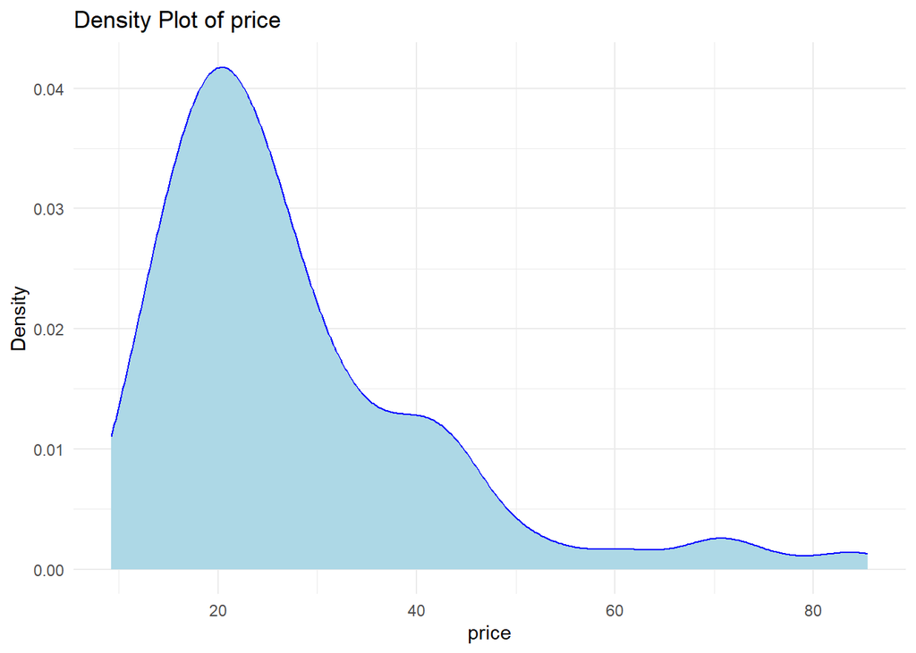

```r
low = min(Sales_Data$price, na.rm = TRUE)
up = max(Sales_Data$price, na.rm = TRUE)
plot_density(Sales_Data, "price")
```

```r
Sales_Data=rand_val(Sales_Data, "price",low,up)

if(any(is.na(Sales_Data$price))){
  print(paste("there are na values", "price"))
}else{
  print(paste("no na values", "price"))
}
```

```
## [1] "no na values price"
```

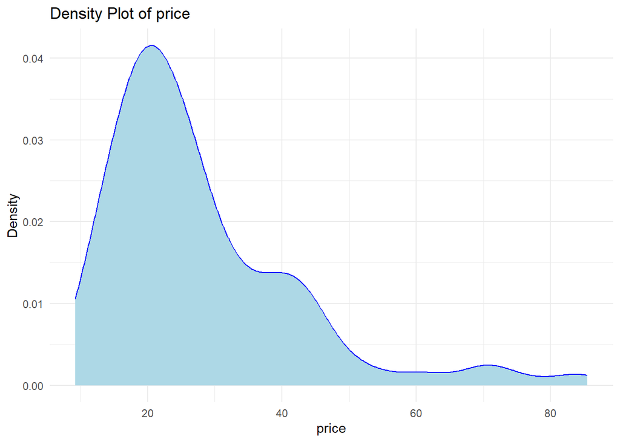

```r
plot_density(Sales_Data, "price")
```

4. **wheelbas**

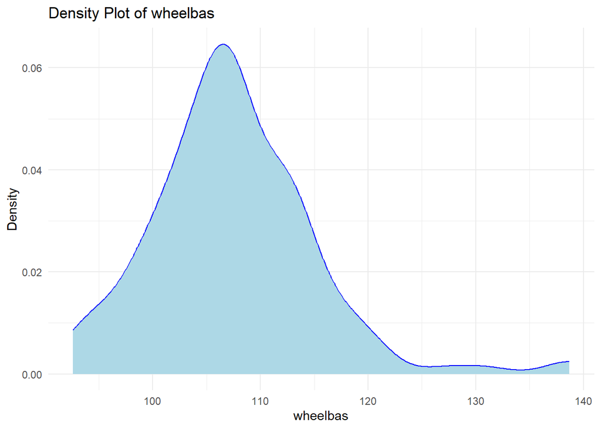

```r
low = min(Sales_Data$wheelbas, na.rm = TRUE)
up = max(Sales_Data$wheelbas, na.rm = TRUE)
plot_density(Sales_Data, "wheelbas")
```

```r
Sales_Data=rand_val(Sales_Data, "wheelbas",low,up)

if(any(is.na(Sales_Data$wheelbas))){
  print(paste("there are na values", "wheelbas"))
}else{
  print(paste("no na values", "wheelbas"))
}
```

```
## [1] "no na values wheelbas"
```

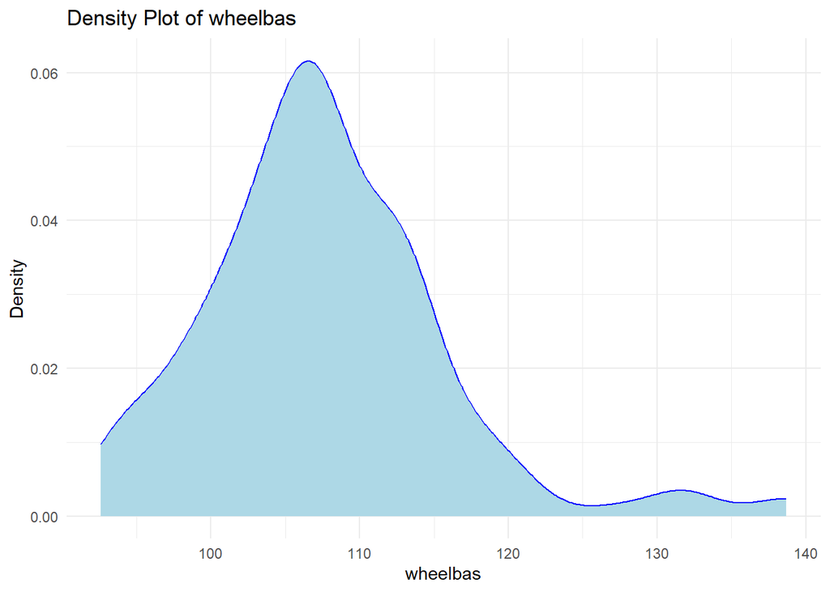

```r
plot_density(Sales_Data, "wheelbas")
```

5. **width**

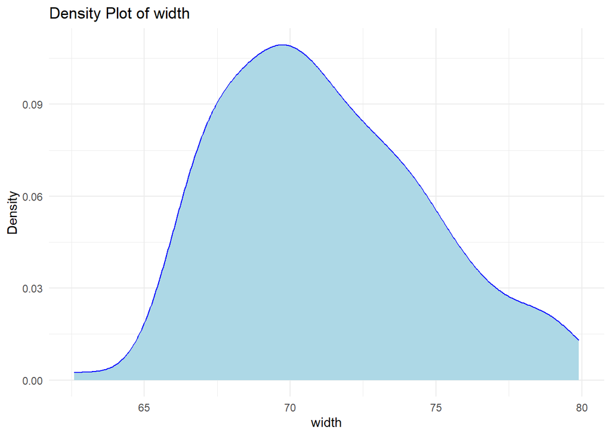

```r
low = min(Sales_Data$width, na.rm = TRUE)
up = max(Sales_Data$width, na.rm = TRUE)
plot_density(Sales_Data, "width")
```

```r
Sales_Data=rand_val(Sales_Data, "width",low,up)

if(any(is.na(Sales_Data$width))){
  print(paste("there are na values", "width"))
}else{
  print(paste("no na values", "width"))
}
```

```
## [1] "no na values width"
```

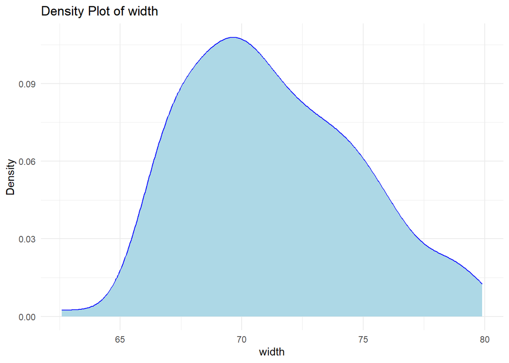

```r
plot_density(Sales_Data, "width")
```

6. **length**

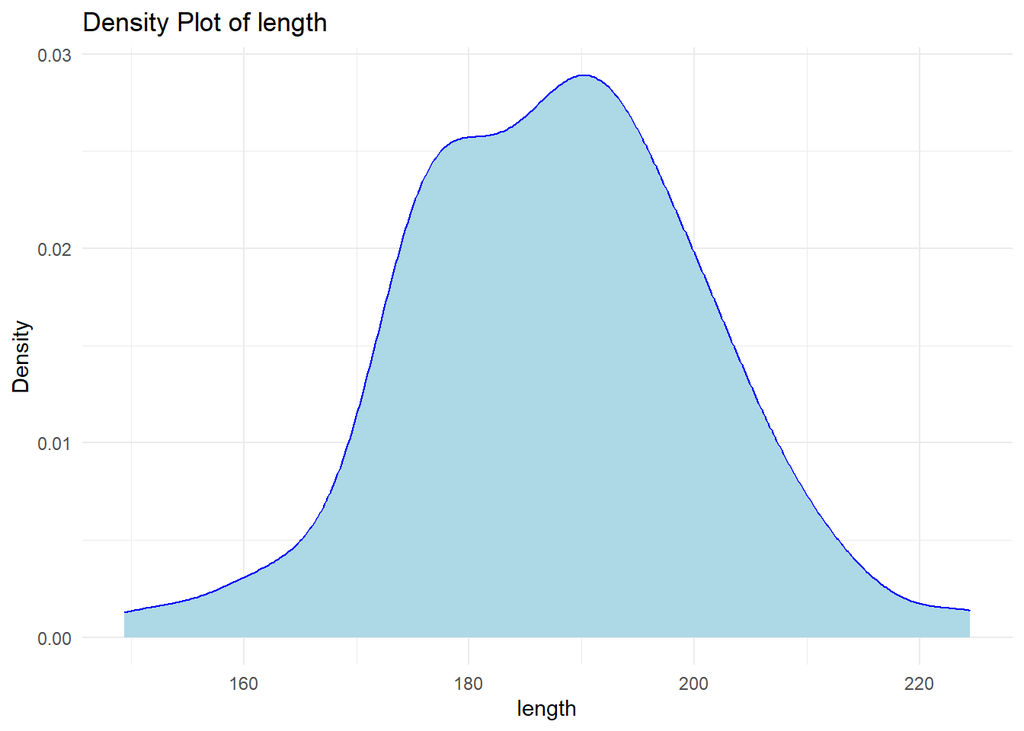

```r
low = min(Sales_Data$length, na.rm = TRUE)
up = max(Sales_Data$length, na.rm = TRUE)
plot_density(Sales_Data, "length")
```

```r
Sales_Data=rand_val(Sales_Data, "length",low,up)

if(any(is.na(Sales_Data$length))){
  print(paste("there are na values", "length"))
}else{
  print(paste("no na values", "length"))
}
```

```
## [1] "no na values length"
```

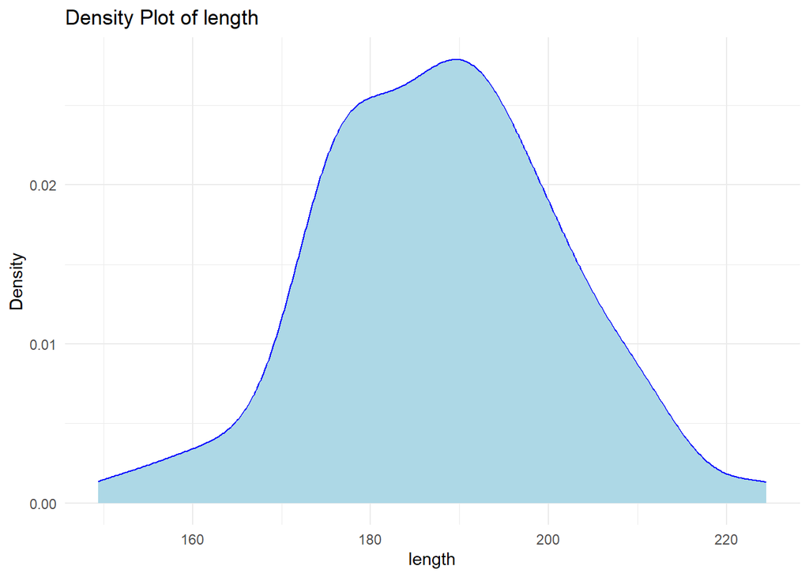

```r
plot_density(Sales_Data, "length")
```

7. **curb_wgt**

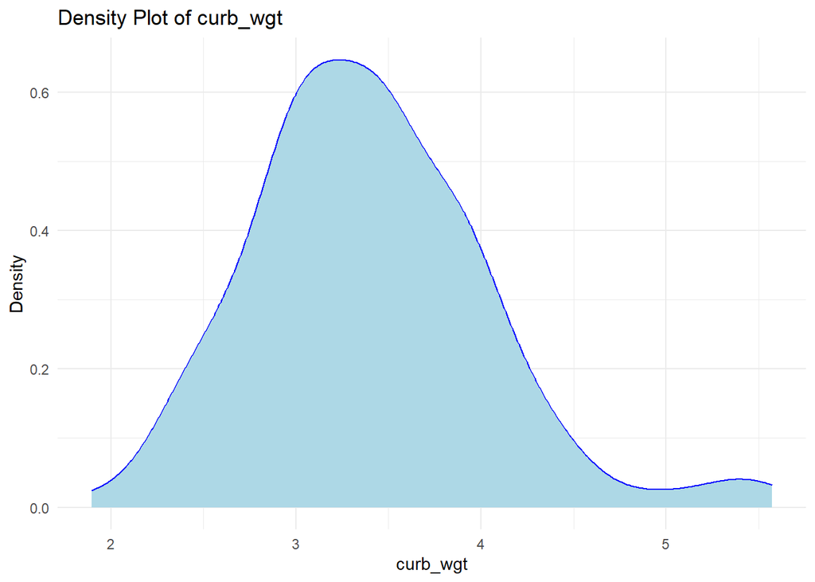

```r
low = min(Sales_Data$curb_wgt, na.rm = TRUE)
up = max(Sales_Data$curb_wgt, na.rm = TRUE)
plot_density(Sales_Data, "curb_wgt")
```

```r
Sales_Data=rand_val(Sales_Data, "curb_wgt",low,up)

if(any(is.na(Sales_Data$curb_wgt))){
  print(paste("there are na values", "curb_wgt"))
}else{
  print(paste("no na values", "curb_wgt"))
}
```

```
## [1] "no na values curb_wgt"
```

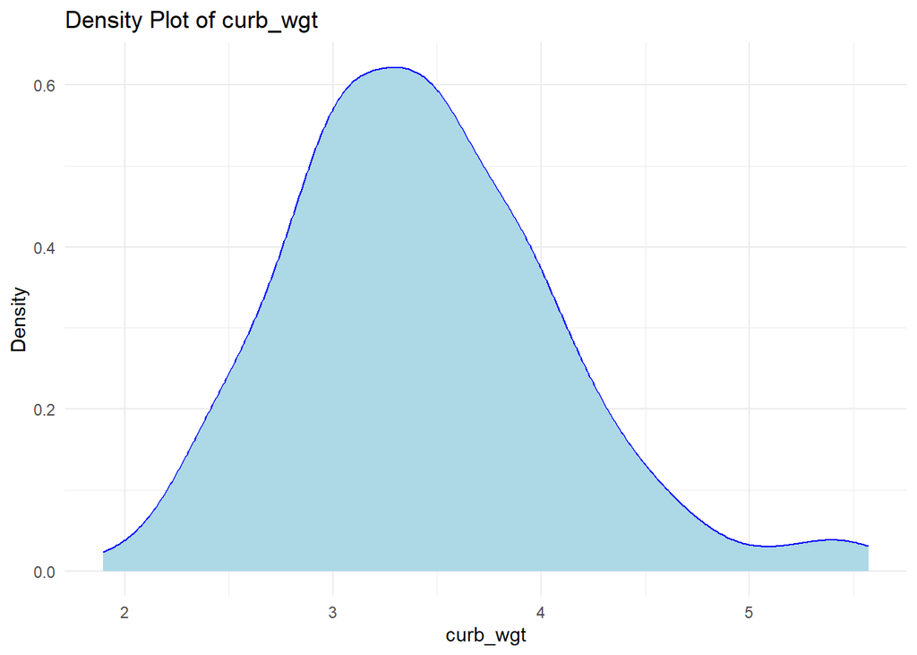

```r
plot_density(Sales_Data, "curb_wgt")
```

8. **fuel_cap**

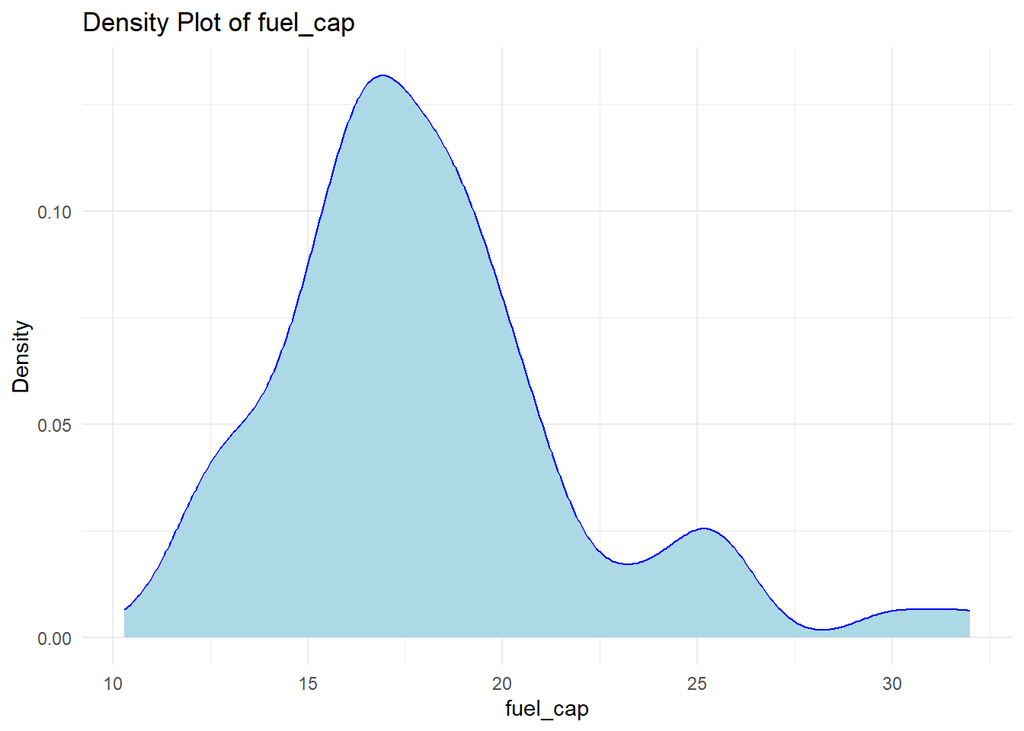

```r
low = min(Sales_Data$fuel_cap, na.rm = TRUE)
up = max(Sales_Data$fuel_cap, na.rm = TRUE)
plot_density(Sales_Data, "fuel_cap")
```

```r
Sales_Data=rand_val(Sales_Data, "fuel_cap",low,up)

if(any(is.na(Sales_Data$fuel_cap))){
  print(paste("there are na values", "fuel_cap"))
}else{
  print(paste("no na values", "fuel_cap"))
}
```

```
## [1] "no na values fuel_cap"
```

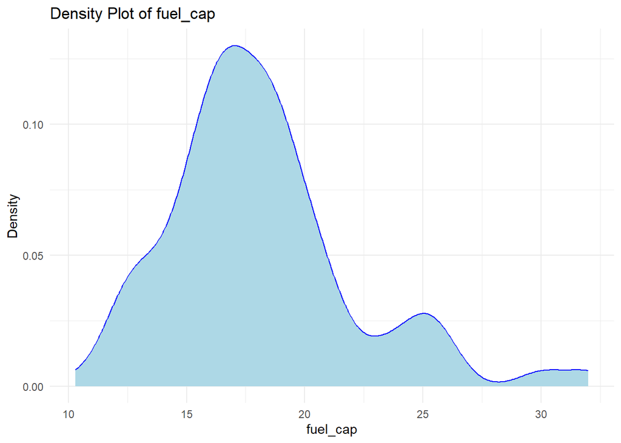

```r
plot_density(Sales_Data, "fuel_cap")
```

# Data Visuals

## spread of price

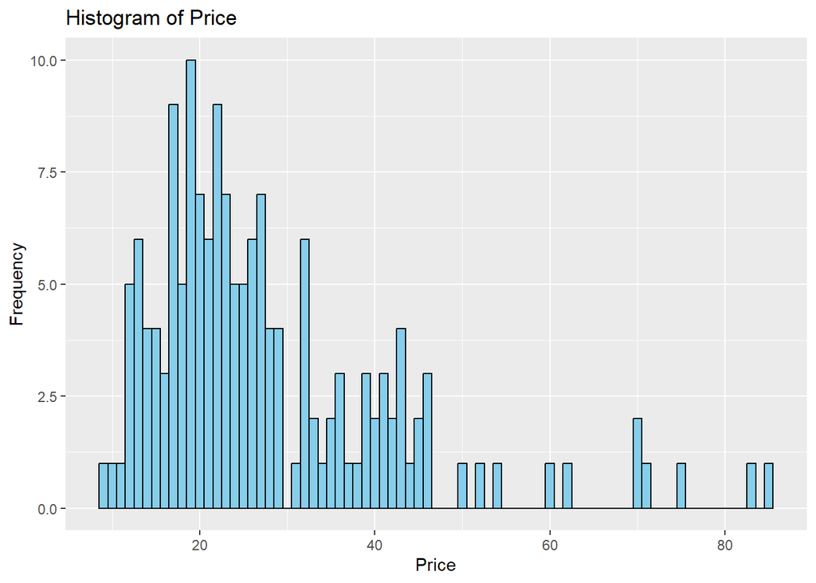

```r
ggplot(Sales_Data, aes(x = Sales_Data$price)) +
  geom_histogram(binwidth = 1, fill = "skyblue", color = "black") +
  labs(x = "Price", y = "Frequency", title = "Histogram of Price")
```

- price has a `right skew`
- This means that most cars in the sales data have a `relatively low prices`

## Engine size and sales

```r
engine_data = Sales_Data[, c(7, 3, 13, 8, 14)]
engine_data$count = rep(1, nrow(Sales_Data))
engine_data = engine_data %>% group_by(engine_s)%>%summarise(
  sales = sum(sales),
  av_fuel_cap = mean(fuel_cap),
  av_horsepow = mean(horsepow),
  av_mpg = mean(mpg)
)
engine_data
```

| engine_s | sales | av_fuel_cap | av_horsepow | av_mpg |
| --- | --- | --- | --- | --- |
| 1.0 | 21.8550 | 10.30000 | 55.0000 | 45.00000 |
| 1.5 | 41.1840 | 11.90000 | 92.0000 | 31.00000 |
| 1.6 | 199.6850 | 11.90000 | 106.0000 | 32.00000 |
| 1.8 | 535.4360 | 14.46082 | 140.3750 | 29.87500 |
| 1.9 | 130.8910 | 16.11936 | 128.8000 | 27.80000 |
| 2.0 | 1166.2610 | 15.19686 | 139.2857 | 26.09524 |
| 2.2 | 451.9740 | 14.75000 | 130.5000 | 27.25000 |
| 2.3 | 271.5020 | 16.20194 | 183.5000 | 25.33333 |
| 2.4 | 555.3961 | 17.11000 | 153.8000 | 25.10000 |
| 2.5 | 639.0190 | 17.52200 | 153.7273 | 23.19091 |

[output cut: 21 more lines]

This data represents the `total sales`, `average horsepower`, `average mpg` and `average fuel capacity` for each engine size

## Regression Analysis

### Variables that influence horse power

```r
# linear regression data
cols_lin_regress = c(3, 4, 6, 7, 8, 9, 10, 11, 12, 13, 14, 15)

#
linear_regress_data = Sales_Data[, cols_lin_regress]
colnames(linear_regress_data)
```

```
##  [1] "sales"     "resale"    "price"     "engine_s"  "horsepow"  "wheelbas"
##  [7] "width"     "length"    "curb_wgt"  "fuel_cap"  "mpg"       "Grp_Horse"
```

```r
linear_model = lm(horsepow~., data = linear_regress_data)
summary(linear_model)
```

```
##
## Call:
## lm(formula = horsepow ~ ., data = linear_regress_data)
##
## Residuals:
##     Min      1Q  Median      3Q     Max
## -54.364  -9.472  -0.782  10.293  48.606
##
## Coefficients:
##              Estimate Std. Error t value Pr(>|t|)
## (Intercept) -20.43295   39.44192  -0.518 0.605212
## sales        -0.00973    0.01824  -0.534 0.594471
## resale        0.12228    0.10523   1.162 0.247159
## price         0.61366    0.16495   3.720 0.000284 ***
## engine_s      7.91240    2.66859   2.965 0.003540 **
## wheelbas      0.23922    0.26266   0.911 0.363936
## width         0.65660    0.58337   1.126 0.262230
## length        0.08431    0.14981   0.563 0.574430
## curb_wgt     -4.81731    3.44938  -1.397 0.164676
## fuel_cap     -0.01132    0.56707  -0.020 0.984098
## mpg          -0.38034    0.53738  -0.708 0.480224
## Grp_Horse    30.50893    2.42547  12.579  < 2e-16 ***
## ---
## Signif. codes:  0 '***' 0.001 '**' 0.01 '*' 0.05 '.' 0.1 ' ' 1
##
## Residual standard error: 15.53 on 145 degrees of freedom
## Multiple R-squared:  0.9291, Adjusted R-squared:  0.9237
## F-statistic: 172.8 on 11 and 145 DF,  p-value: < 2.2e-16
```

```r
linear_model_2 = lm(horsepow~Grp_Horse+engine_s+price, data = linear_regress_data)
summary(linear_model_2)
```

```
##
## Call:
## lm(formula = horsepow ~ Grp_Horse + engine_s + price, data = linear_regress_data)
##
## Residuals:
##     Min      1Q  Median      3Q     Max
## -59.649 -10.045  -0.976   9.151  47.220
##
## Coefficients:
##             Estimate Std. Error t value Pr(>|t|)
## (Intercept)  36.9584     3.8874   9.507  < 2e-16 ***
## Grp_Horse    31.6802     2.0902  15.156  < 2e-16 ***
## engine_s      9.1476     1.9125   4.783 4.03e-06 ***
## price         0.6113     0.1398   4.372 2.27e-05 ***
## ---
## Signif. codes:  0 '***' 0.001 '**' 0.01 '*' 0.05 '.' 0.1 ' ' 1
##
## Residual standard error: 15.5 on 153 degrees of freedom
## Multiple R-squared:  0.9255, Adjusted R-squared:  0.924
## F-statistic: 633.2 on 3 and 153 DF,  p-value: < 2.2e-16
```

From the data the `horse power` can be predicted based on `Grp horse`, `engine size`, and `price`

## Homoscedasticity

```r
library(lmtest)
homoscedasticity_test = bptest(linear_model_2)
homoscedasticity_test
```

```
##
##  studentized Breusch-Pagan test
##
## data:  linear_model_2
## BP = 6.2685, df = 3, p-value = 0.09925
```

## Normality Test

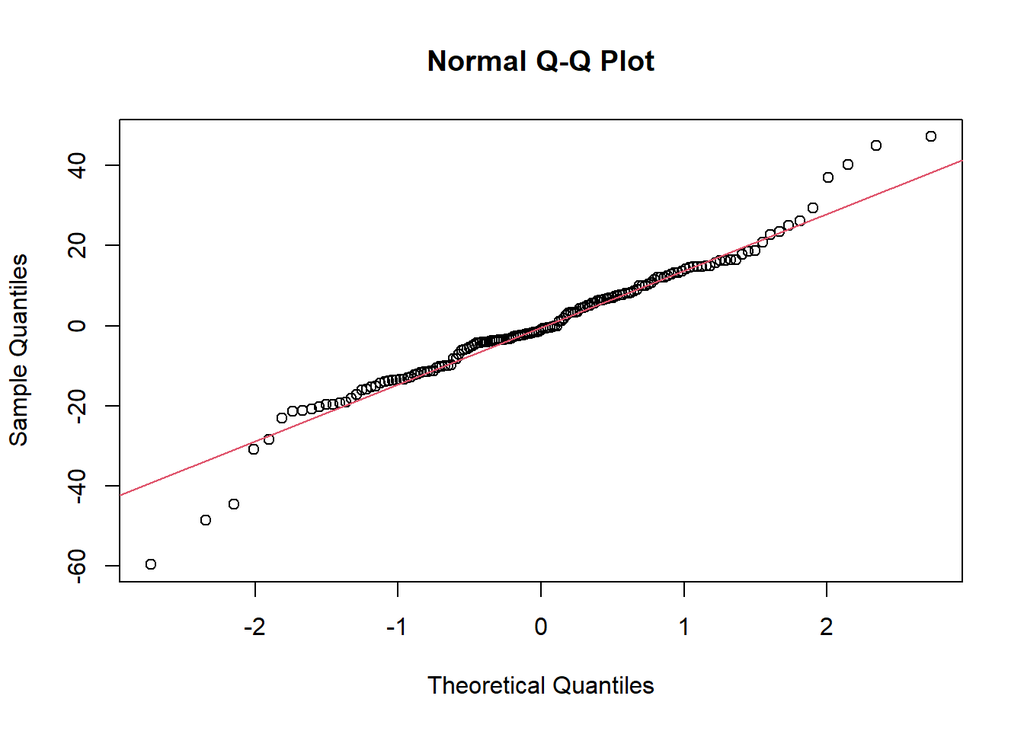

```r
linear_residuals = residuals(linear_model_2)

# qqplot
qqnorm(linear_residuals)
qqline(linear_residuals, col = 2)
```

Most of the points lie on the qqline indicating that the variables follow a normal distribution

## linearity

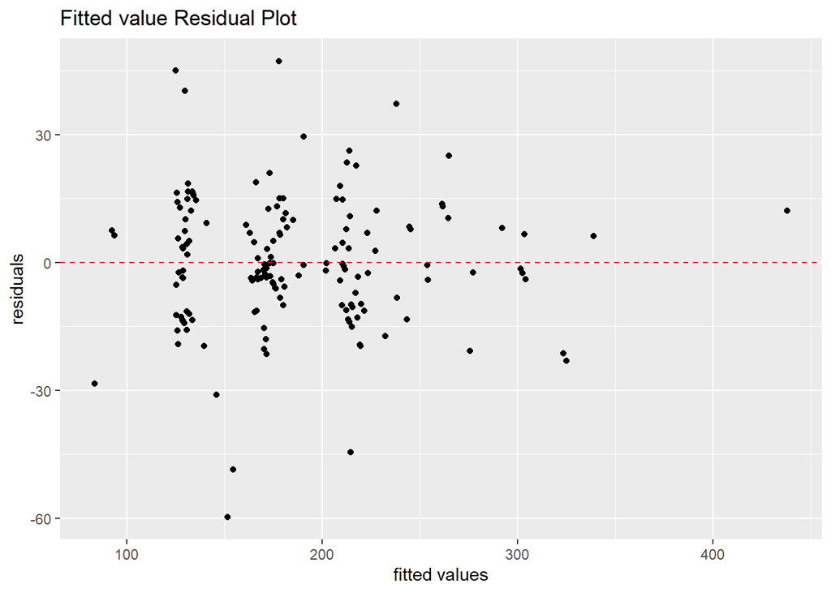

```r
library(ggplot2)

res_fit = data.frame(fitted = linear_model_2$fitted.values,
                     residual = linear_model_2$residuals)

ggplot(data = res_fit,
       aes(x = fitted, y = residual)) +
  geom_point()+
  geom_hline(yintercept = 0, linetype = "dashed", color = "red") +
  labs(
    x = "fitted values",
    y = "residuals",
    title = "Fitted value Residual Plot"
  )
```

Most data points are around the `0` line and equally distributed either side meaning that the relationship of the dependent and independent variables is `linear`

## multi-colinearity

```r
library(car)
var_inf= vif(linear_model_2)
var_inf
```

```
## Grp_Horse  engine_s     price
##  4.334942  2.595881  2.600109
```

The variance inflation factor for each of the variables is `less than 5` indicating that the variables are not affected by variance inflation due to **multi-colinearity**

# Factor analysis

## Corelation

```r
pca_data = linear_regress_data
pca_data = pca_data %>% select_if(is.numeric)
data_pca_cor = cor(pca_data)
data_pca_cor
```

```
##                 sales      resale      price    engine_s   horsepow   wheelbas
## sales      1.00000000 -0.16276349 -0.1873191  0.06629281 -0.1610154  0.2929246
## resale    -0.16276349  1.00000000  0.6323118  0.24522998  0.4990608 -0.0339904
## price     -0.18731914  0.63231178  1.0000000  0.59703820  0.8031983  0.1228932
## engine_s   0.06629281  0.24522998  0.5970382  1.00000000  0.8087624  0.4538559
## horsepow  -0.16101535  0.49906075  0.8031983  0.80876242  1.0000000  0.2766618
## wheelbas   0.29292462 -0.03399040  0.1228932  0.45385587  0.2766618  1.0000000
## width      0.18104918  0.03700733  0.3076397  0.65492259  0.5237805  0.6312630
## length     0.25877541 -0.04023432  0.1397068  0.50425732  0.3670983  0.7289188
## curb_wgt   0.11946340  0.19876452  0.4305241  0.67070168  0.5099005  0.6123179
## fuel_cap   0.15699744  0.16861614  0.3815604  0.62011154  0.4631360  0.6220117
## mpg       -0.09207295 -0.27561450 -0.4555549 -0.70979814 -0.5890175 -0.4829163
## Grp_Horse -0.20985729  0.49254674  0.7839818  0.78358145  0.9517768  0.2111272
##                 width      length   curb_wgt   fuel_cap         mpg  Grp_Horse
## sales      0.18104918  0.25877541  0.1194634  0.1569974 -0.09207295 -0.2098573
## resale     0.03700733 -0.04023432  0.1987645  0.1686161 -0.27561450  0.4925467
## price      0.30763967  0.13970684  0.4305241  0.3815604 -0.45555494  0.7839818
## engine_s   0.65492259  0.50425732  0.6707017  0.6201115 -0.70979814  0.7835815
## horsepow   0.52378049  0.36709831  0.5099005  0.4631360 -0.58901747  0.9517768
## wheelbas   0.63126304  0.72891875  0.6123179  0.6220117 -0.48291626  0.2111272
## width      1.00000000  0.64678859  0.6495424  0.5948525 -0.56861801  0.4849317
## length     0.64678859  1.00000000  0.5504010  0.5232562 -0.42935630  0.3324329
## curb_wgt   0.64954241  0.55040097  1.0000000  0.7323449 -0.72351235  0.4700743
## fuel_cap   0.59485251  0.52325618  0.7323449  1.0000000 -0.74628095  0.4061093
## mpg       -0.56861801 -0.42935630 -0.7235123 -0.7462810  1.00000000 -0.5497823
## Grp_Horse  0.48493167  0.33243293  0.4700743  0.4061093 -0.54978227  1.0000000
```

## Principle components

```r
pca_result = prcomp(pca_data, scale = TRUE) # std dev = 1 and mean = 0
summary(pca_result)
```

```
## Importance of components:
##                          PC1    PC2     PC3     PC4     PC5     PC6     PC7
## Standard deviation     2.471 1.5354 0.90156 0.84401 0.76143 0.56660 0.53756
## Proportion of Variance 0.509 0.1965 0.06773 0.05936 0.04832 0.02675 0.02408
## Cumulative Proportion  0.509 0.7055 0.77319 0.83255 0.88087 0.90762 0.93170
##                           PC8    PC9    PC10   PC11    PC12
## Standard deviation     0.5102 0.4725 0.41636 0.3447 0.20937
## Proportion of Variance 0.0217 0.0186 0.01445 0.0099 0.00365
## Cumulative Proportion  0.9534 0.9720 0.98644 0.9963 1.00000
```

- **Standard deviation:** Indicates the amount of variance captured by each principal component. Larger standard deviations mean that the principal component captures more variability in the data.
- **Proportion of Variance:** Represents the proportion of total variance in the data explained by each principal component. Higher values indicate that the corresponding principal component explains more of the total variance.
- **Cumulative Proportion:** Shows the cumulative proportion of variance explained by each principal component. It demonstrates how much of the total variance is explained when considering up to that specific component.

## Scree plot

```r
library(psych)
library(FactoMineR)
library(factoextra)
```

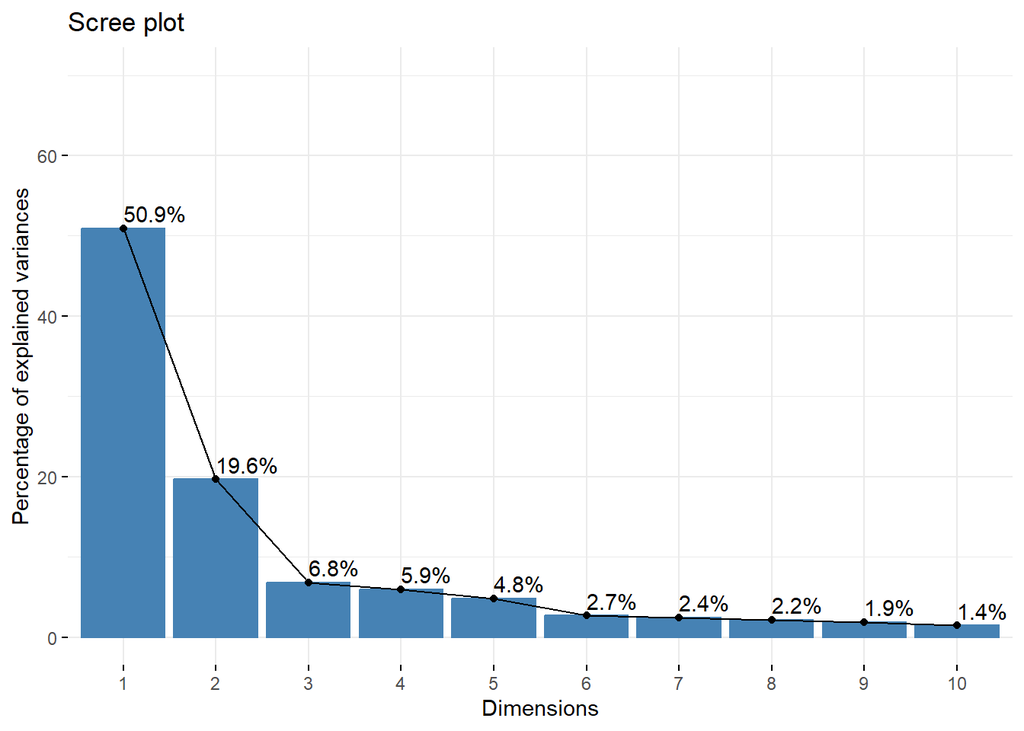

```r
fviz_eig(pca_result,
         addlabels = TRUE,
         ylim = c(0, 70))
```

## Key components

```r
pca_result$rotation
```

```
##                   PC1         PC2         PC3         PC4         PC5
## sales      0.02801991 -0.39146491 -0.72824122  0.47434145 -0.25947488
## resale     0.15459699  0.41010607 -0.52490873 -0.09122945  0.53795241
## price      0.27624717  0.38222145 -0.15672506  0.08104079  0.06323395
## engine_s   0.35971691  0.04154886  0.09328298  0.17078480 -0.35313471
## horsepow   0.33930009  0.28254512  0.10539473  0.25935123 -0.07632581
## wheelbas   0.25615962 -0.37994353  0.04406977 -0.02832187  0.45179098
## width      0.31090849 -0.21421518  0.21298643  0.18043702 -0.01592310
## length     0.26061334 -0.32785702  0.20075047  0.28995432  0.43691067
## curb_wgt   0.33145475 -0.14622482 -0.04925159 -0.34071829 -0.02268641
## fuel_cap   0.31674455 -0.17745669 -0.12839155 -0.45021533 -0.07171826
## mpg       -0.33132455  0.04798343  0.14092724  0.38915003  0.31431802
## Grp_Horse  0.32297814  0.31305991  0.15292591  0.27572731 -0.09506913
##                   PC6          PC7          PC8         PC9         PC10
## sales     -0.01349878 -0.061914986  0.015880432 -0.01900519  0.022119023
## resale     0.19348052  0.349243887  0.012497850  0.02717674 -0.254512729
## price     -0.01727656 -0.578790390 -0.066726000 -0.15436289  0.513725233
## engine_s  -0.13353429  0.044375120  0.104548053  0.17602133 -0.485120475
## horsepow  -0.11885743  0.009868017 -0.073362806  0.07364515 -0.040558721
## wheelbas  -0.15334541 -0.258580028 -0.235312766  0.65874624 -0.006607236
## width      0.80702771  0.129258716 -0.296548387 -0.10442063  0.094011924
## length    -0.32902532  0.269812040  0.270164943 -0.45595048  0.171338823
## curb_wgt   0.26495404 -0.302252468  0.722981931 -0.01772652 -0.123844270
## fuel_cap  -0.21017229 -0.149071571 -0.489585571 -0.47980513 -0.304482291
## mpg        0.13614331 -0.512535226 -0.009097366 -0.23103185 -0.530450581
## Grp_Horse -0.11896158  0.067001254 -0.006712197  0.04495743 -0.078548983
##                  PC11         PC12
## sales     -0.13384273 -0.016601552
## resale     0.09780498 -0.004968532
## price      0.33335581 -0.062037187
## engine_s   0.63927021 -0.024114670
## horsepow  -0.37257663  0.745223753
## wheelbas  -0.03257108 -0.048622085
## width      0.05862625 -0.012331119
## length     0.13366736  0.012851691
## curb_wgt  -0.22122241  0.029591204
## fuel_cap  -0.12043678 -0.018548899
## mpg       -0.04059747  0.010759539
## Grp_Horse -0.47587505 -0.660222942
```

## Transform based on the principle components

```r
transformed = predict(pca_result, newdata =linear_regress_data)
head(transformed)
```

```
##            PC1        PC2         PC3        PC4          PC5          PC6
## [1,] -7.697833  0.9971431  0.33472084  0.7813615  0.259227186  0.246969726
## [2,] -4.681275  0.6471470  0.39221009  0.4498964 -0.614188614 -0.215611207
## [3,] -3.348675 -1.0747948 -0.17760853 -0.5583321  0.192618433  0.760073882
## [4,] -3.806484 -0.3566017  0.22944466 -0.3599750  0.011007536 -0.495446793
## [5,] -3.032689  0.5151325  0.10805642 -0.3738306  0.005209257 -0.167313542
## [6,] -2.305791  0.3768733 -0.06481067 -0.5402502  0.337009573 -0.005049921
##              PC7         PC8          PC9        PC10         PC11       PC12
## [1,] -2.05586201 -0.34207160 -0.218148471 -1.71006608  0.123219131 -0.2675489
## [2,] -0.03649063 -0.09930098  0.003465122 -0.19745855 -0.419185034 -0.8951056
## [3,] -1.53099151  2.55506566  0.052754641 -0.86078870 -0.257810481  0.3324137
## [4,]  0.58752904  0.04039991  0.449957808  0.66378918  0.785414769  0.2127899
## [5,] -0.29599761 -0.39840067 -0.033848420  0.07201925  0.046233428  0.1726140
## [6,] -0.24755394 -0.12178915 -0.194520552  0.15177164 -0.006141159  0.2955186
```

It is clear that `pc12` experiences the least variance captured by the dimension reduction

## Data point labels

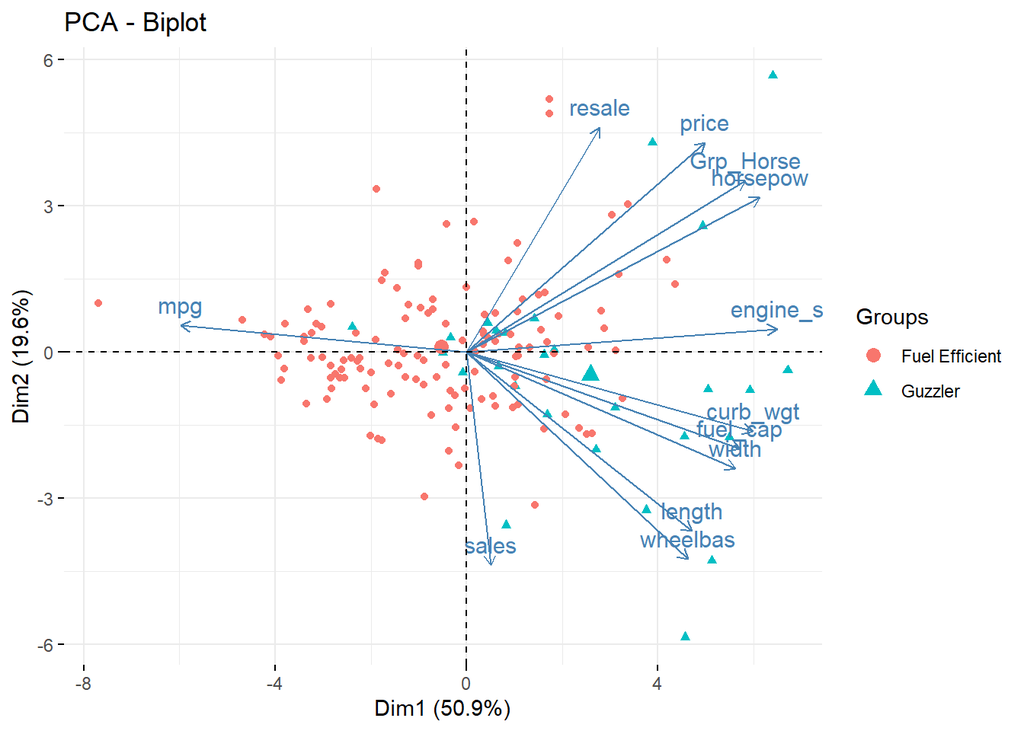

```r
linear_regress_data$mpg = ifelse(linear_regress_data$mpg < 21, 'Guzzler', "Fuel Efficient")
linear_regress_data$mpg = as.factor(linear_regress_data$mpg)
fviz_pca_biplot(pca_result,
                label = "var",
                habillage = linear_regress_data$mpg)
```

The higher the `mpg` the more likely the car is fuel efficient

```r
colnames(linear_regress_data)
```

```
##  [1] "sales"     "resale"    "price"     "engine_s"  "horsepow"  "wheelbas"
##  [7] "width"     "length"    "curb_wgt"  "fuel_cap"  "mpg"       "Grp_Horse"
```

`` resale, price, engine size, horsepow` `` increase with a decrease in fuel efficiency

`sales` has a negative non impact to being a guzzler or not